# EDA on Diabetes Disease

## Objective

Main objective behind this notebook is to get an insight of the data and to explore different aspects of it.

## Content

- 1. Load libraries and Read data
     - 1.1. Load libraries
     - 1.2. Read data
- 1. Overview
     - 2.1. Head
     - 2.2. Target
     - 2.3. Missing values
- 1. Replacing missing values
     - 3.1. Glucose
     - 3.2. BloodPressure
     - 3.3. SkinThickness
     - 3.4. Insulin
     - 3.5. BMI
     - 3.6. Remaining distributions
- 1. Feature Analysis
     - 4.1. Pregnancies vs Age
     - 4.2. Glucose vs Insulin
     - 4.3. SkinThickness vs BMI
     - 4.4. Glucose vs Age
     - 4.5. Glucose vs BloodPressure
     - 4.6. Glucose vs BMI

## Attribute Information

1. Pregnancies : Number of times pregnant
2. Glucose : Plasma glucose concentration a 2 hours in an oral glucose tolerance test
3. BloodPressure : Diastolic blood pressure (mm Hg)
4. SkinThickness : Triceps skin fold thickness (mm)
5. Insulin : 2-Hour serum insulin (mu U/ml)
6. BMI : Body mass index (weight in kg/(height in m)^2)
7. Age : Age (years)
8. DiabetesPedigreeFunction : It provides information about diabetes history in relatives and genetic relationship of those relatives with patients.
9. Outcome : Target

## 1. Load libraries and Read data

### 1.1. Load libraries

Loading the libraries

```python
import pandas as pd
import numpy as np
import matplotlib.pyplot as plt
import seaborn as sns
import warnings
warnings.filterwarnings('ignore')
```

Setting the default values for plots

```python
plt.rc('axes', titlesize=18)
plt.rc('axes', labelsize=15)
plt.rc('xtick', labelsize=13)
plt.rc('ytick', labelsize=13)
plt.rc('figure', titlesize=35)
plt.rc('legend', fontsize=12)
```

### 1.2. Read data

Reading the data with pandas

```python
df=pd.read_csv('diabetes.csv')
```

## 2. Overview

### 2.1. Head

Checking data head, info, summary statistics and null values

```python
df.head()
```

|  | Pregnancies | Glucose | BloodPressure | SkinThickness | Insulin | BMI | DiabetesPedigreeFunction | Age | Outcome |
| --- | --- | --- | --- | --- | --- | --- | --- | --- | --- |
| 0 | 6 | 148 | 72 | 35 | 0 | 33.6 | 0.627 | 50 | 1 |
| 1 | 1 | 85 | 66 | 29 | 0 | 26.6 | 0.351 | 31 | 0 |
| 2 | 8 | 183 | 64 | 0 | 0 | 23.3 | 0.672 | 32 | 1 |
| 3 | 1 | 89 | 66 | 23 | 94 | 28.1 | 0.167 | 21 | 0 |
| 4 | 0 | 137 | 40 | 35 | 168 | 43.1 | 2.288 | 33 | 1 |

```python
df.info()
```

```
<class 'pandas.core.frame.DataFrame'>
RangeIndex: 768 entries, 0 to 767
Data columns (total 9 columns):
 #   Column                    Non-Null Count  Dtype
---  ------                    --------------  -----
 0   Pregnancies               768 non-null    int64
 1   Glucose                   768 non-null    int64
 2   BloodPressure             768 non-null    int64
 3   SkinThickness             768 non-null    int64
 4   Insulin                   768 non-null    int64
 5   BMI                       768 non-null    float64
 6   DiabetesPedigreeFunction  768 non-null    float64
 7   Age                       768 non-null    int64
 8   Outcome                   768 non-null    int64
dtypes: float64(2), int64(7)
memory usage: 54.1 KB
```

```python
df.describe()
```

|  | Pregnancies | Glucose | BloodPressure | SkinThickness | Insulin | BMI | DiabetesPedigreeFunction | Age | Outcome |
| --- | --- | --- | --- | --- | --- | --- | --- | --- | --- |
| count | 768.000000 | 768.000000 | 768.000000 | 768.000000 | 768.000000 | 768.000000 | 768.000000 | 768.000000 | 768.000000 |
| mean | 3.845052 | 120.894531 | 69.105469 | 20.536458 | 79.799479 | 31.992578 | 0.471876 | 33.240885 | 0.348958 |
| std | 3.369578 | 31.972618 | 19.355807 | 15.952218 | 115.244002 | 7.884160 | 0.331329 | 11.760232 | 0.476951 |
| min | 0.000000 | 0.000000 | 0.000000 | 0.000000 | 0.000000 | 0.000000 | 0.078000 | 21.000000 | 0.000000 |
| 25% | 1.000000 | 99.000000 | 62.000000 | 0.000000 | 0.000000 | 27.300000 | 0.243750 | 24.000000 | 0.000000 |
| 50% | 3.000000 | 117.000000 | 72.000000 | 23.000000 | 30.500000 | 32.000000 | 0.372500 | 29.000000 | 0.000000 |
| 75% | 6.000000 | 140.250000 | 80.000000 | 32.000000 | 127.250000 | 36.600000 | 0.626250 | 41.000000 | 1.000000 |
| max | 17.000000 | 199.000000 | 122.000000 | 99.000000 | 846.000000 | 67.100000 | 2.420000 | 81.000000 | 1.000000 |

```python
df.isnull().any()
```

```
Pregnancies                 False
Glucose                     False
BloodPressure               False
SkinThickness               False
Insulin                     False
BMI                         False
DiabetesPedigreeFunction    False
Age                         False
Outcome                     False
dtype: bool
```

The dataset consists of several medical predictor variables and one target variable, Outcome. Independent variables include the number of pregnancies the female had, their BMI, insulin level, age, and so on. The dataset consists of 768 entries with non-null values.

### 2.2. Target

How many females are suffering from Diabetes Disease ?

What is the target distribution ?

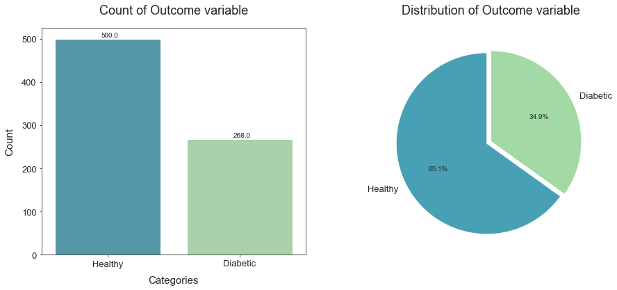

```python
fig,ax=plt.subplots(1,2,figsize=(15,6))
sns.set_style('ticks')
sns.set_palette('Spectral_r')
sns.barplot(x=['Healthy','Diabetic'], y=df['Outcome'].value_counts().values,ax=ax[0])
ax[0].set_title('Count of Outcome variable',pad=20)
ax[0].set_ylabel('Count',labelpad=10)
ax[0].set_xlabel('Categories',labelpad=10)
plt.pie(df['Outcome'].value_counts(),explode=[0.05,0.0],labels=['Healthy','Diabetic'],startangle=90,autopct='%1.1f%%')
plt.title('Distribution of Outcome variable',pad=20)
for p in ax[0].patches:
    ax[0].annotate(str(p.get_height()), (p.get_x(), p.get_height()),xytext=(p.get_x()+0.35,p.get_height()+5))
plt.show()
```

From the above graph we can say that less than half of the females are suffering from Diabetes Disease with parcentage of 34.9%.

```python
print(df['Outcome'].value_counts())
```

```
0    500
1    268
Name: Outcome, dtype: int64
```

500 of the females are healthy while other 268 are diabetic

### 2.3. Missing values

We saw above in data head that some features contain 0. It doesn't make sense here and this indicates that there are missing values in our data.

Let's replace 0 value by NaN

```python
df[['Glucose','BloodPressure','SkinThickness','Insulin','BMI']] = df[['Glucose','BloodPressure','SkinThickness','Insulin','BMI']].replace(0,np.NaN)
```

Now, let's take a look at those missing values

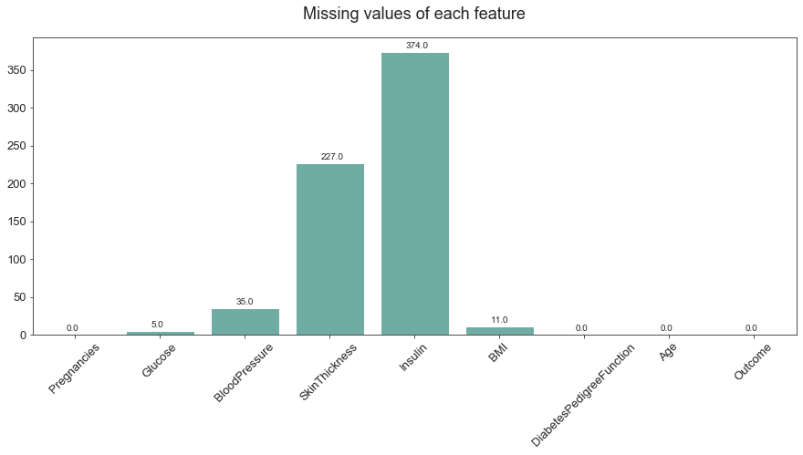

```python
plt.figure(figsize=(15,6))
ax=sns.barplot(x=df.columns,y=df.isnull().sum(),color = '#64B6AC')
ax.set_xticklabels(ax.get_xticklabels(),rotation=45)
plt.title('Missing values of each feature',pad=20)
for p in ax.patches:
    ax.annotate(str(p.get_height()), (p.get_x(), p.get_height()),xytext=(p.get_x()+0.3,p.get_height()+5))
plt.show()
```

Missing values

```python
print(df.isnull().sum())
```

```
Pregnancies                   0
Glucose                       5
BloodPressure                35
SkinThickness               227
Insulin                     374
BMI                          11
DiabetesPedigreeFunction      0
Age                           0
Outcome                       0
dtype: int64
```

Let's get some more insight's about the features with box plot

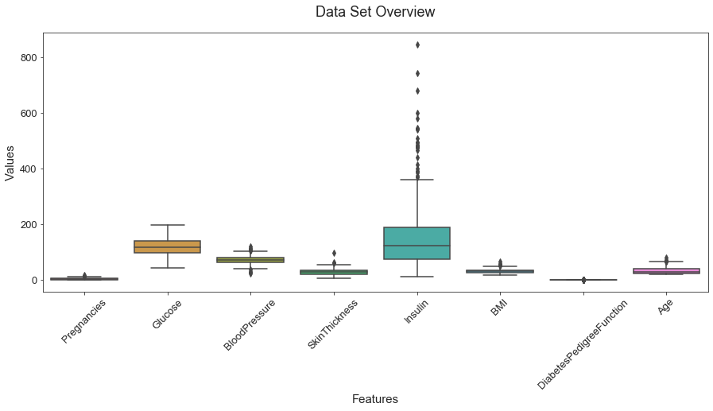

```python
df_melted=pd.melt(frame=df,id_vars='Outcome',var_name='Features',value_name='Values')
fig,ax=plt.subplots(figsize=(15,6))
ax=sns.boxplot(x='Features',y='Values',data=df_melted)
ax.set_xticklabels(ax.get_xticklabels(),rotation=45)
plt.title('Data Set Overview',pad=20)
plt.show()
```

From above plot we can see that there are outliers in the data and those outliers might be valid values so we can't replace the missing values with the mean instead we will use the median by target to replace the missing data to get a much more realistic data.

## 3. Replacing missing values

We will divide the data set into two parts with diabetic and healthy females.

```python
def take_median(feature):
    temp = df.groupby(['Outcome'])[[feature]].median().reset_index()
    return temp
```

```python
df_dang=df[df['Outcome']!=0]
df_safe=df[df['Outcome']==0]

def dist_plot(feature,bins):
    plt.figure(figsize=(15,6))
    sns.set_palette('Set1')
    ax=sns.distplot(df_dang[feature].dropna(),hist=True,kde=True,bins=bins,label='Diabetic')
    ax=sns.distplot(df_safe[feature].dropna(),hist=True,kde=True,bins=bins,label='Healthy')
    ax.set_xlabel(None)
    ax.legend()
    plt.title(feature,pad=20)
    plt.show()
```

### 3.1. Glucose

**Glucose** : Plasma glucose concentration a 2 hours in an oral glucose tolerance test

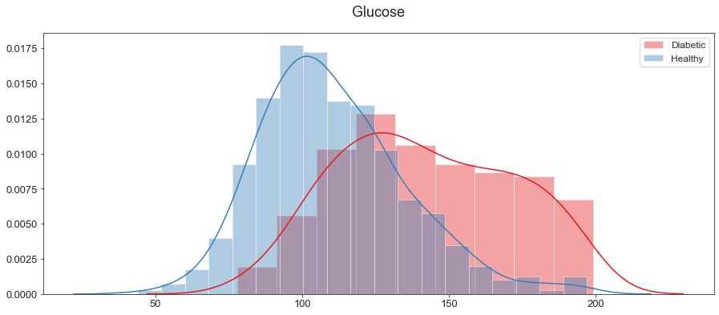

```python
dist_plot('Glucose',None)
```

```python
take_median('Glucose')
```

|  | Outcome | Glucose |
| --- | --- | --- |
| 0 | 0 | 107.0 |
| 1 | 1 | 140.0 |

We got 107 Plasma glucose concentration level for non diabetic females and 140 for diabetic females

Replacing the NaN values in data sets with the resultant values

```python
df.loc[(df['Outcome'] == 0 ) & (df['Glucose'].isnull()),'Glucose'] = 107
df.loc[(df['Outcome'] != 0 ) & (df['Glucose'].isnull()),'Glucose'] = 140
```

### 3.2. BloodPressure

**BloodPressure** : Diastolic blood pressure (mm Hg)

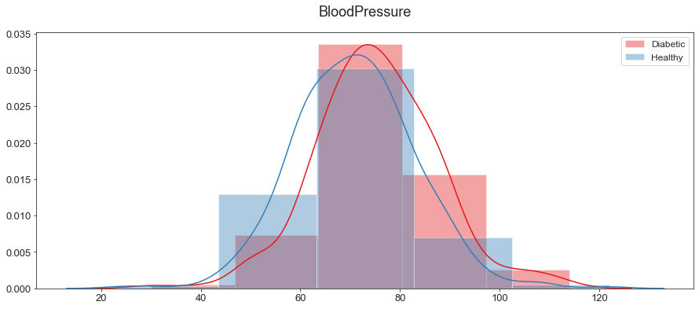

```python
dist_plot('BloodPressure',5)
```

```python
take_median('BloodPressure')
```

|  | Outcome | BloodPressure |
| --- | --- | --- |
| 0 | 0 | 70.0 |
| 1 | 1 | 74.5 |

We got 70 Diastolic blood pressure for non diabetic females and 74.5 for diabetic females

Replacing the NaN values in data sets with the resultant values

```python
df.loc[(df['Outcome'] == 0 ) & (df['BloodPressure'].isnull()),'BloodPressure'] = 70
df.loc[(df['Outcome'] != 0 ) & (df['BloodPressure'].isnull()),'BloodPressure'] = 74.5
```

### 3.3. SkinThickness

**SkinThickness** : Triceps skin fold thickness (mm)

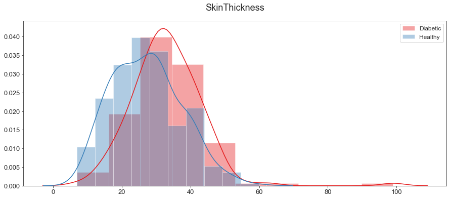

```python
dist_plot('SkinThickness',10)
```

```python
take_median('SkinThickness')
```

|  | Outcome | SkinThickness |
| --- | --- | --- |
| 0 | 0 | 27.0 |
| 1 | 1 | 32.0 |

We got 27 Triceps skin fold thickness for non diabetic females and 32 for diabetic females

Replacing the NaN values in data sets with the resultant values

```python
df.loc[(df['Outcome'] == 0 ) & (df['SkinThickness'].isnull()),'SkinThickness'] = 27
df.loc[(df['Outcome'] != 0 ) & (df['SkinThickness'].isnull()),'SkinThickness'] = 32
```

### 3.4. Insulin

**Insulin** : 2-Hour serum insulin (mu U/ml)

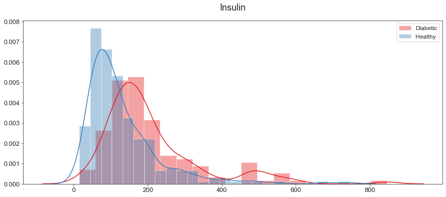

```python
dist_plot('Insulin',None)
```

```python
take_median('Insulin')
```

|  | Outcome | Insulin |
| --- | --- | --- |
| 0 | 0 | 102.5 |
| 1 | 1 | 169.5 |

We got 102.5 serum insulin for non diabetic females and 169.5 for diabetic females

Replacing the NaN values in data sets with the resultant values

```python
df.loc[(df['Outcome'] == 0 ) & (df['Insulin'].isnull()),'Insulin'] = 102.5
df.loc[(df['Outcome'] != 0 ) & (df['Insulin'].isnull()),'Insulin'] = 169.5
```

### 3.5. BMI

**BMI** : Body mass index (weight in kg/(height in m)^2)

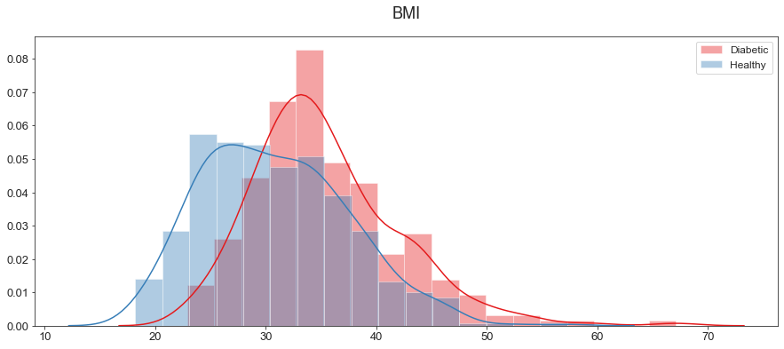

```python
dist_plot('BMI',None)
```

```python
take_median('BMI')
```

|  | Outcome | BMI |
| --- | --- | --- |
| 0 | 0 | 30.1 |
| 1 | 1 | 34.3 |

We got 30.1 Body mass index for non diabetic females and 34.3 for diabetic females

Replacing the NaN values in data sets with the resultant values

```python
df.loc[(df['Outcome'] == 0 ) & (df['BMI'].isnull()),'BMI'] = 30.1
df.loc[(df['Outcome'] != 0 ) & (df['BMI'].isnull()),'BMI'] = 34.3
```

### 3.6. Remaining distributions

- **Pregnancies** : Number of times pregnant
- **Age** : Age (years)
- **DiabetesPedigreeFunction** : Information about diabetes history in relatives and genetic relationship of those relatives with patients.

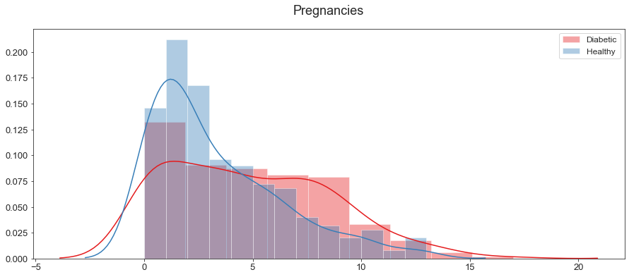

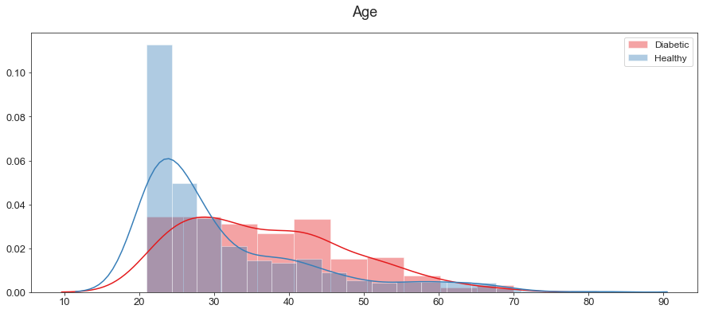

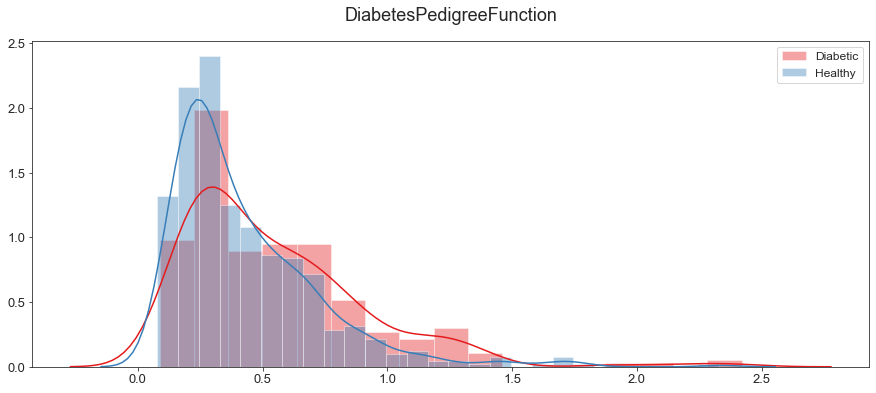

```python
dist_plot('Pregnancies',None)
dist_plot('Age',None)
dist_plot('DiabetesPedigreeFunction',None)
```

Now let's again take a look at our new data

```python
print(df.isnull().sum())
```

```
Pregnancies                 0
Glucose                     0
BloodPressure               0
SkinThickness               0
Insulin                     0
BMI                         0
DiabetesPedigreeFunction    0
Age                         0
Outcome                     0
dtype: int64
```

All the features are complete.

Let's save this data set to use it later for our model.

```python
df.to_csv('diabetes_new.csv', index=False)
```

## 4. Feature analysis

Let's explore more feature to get more insight from dataset

```python
def feature_analysis(x_feat,y_feat):
    sns.set_style('darkgrid')
    sns.set_palette('Set1')
    x=sns.relplot(x=x_feat,y=y_feat,hue='Outcome',style='Outcome',data=df,kind='scatter',height=5,aspect=2.5)
    plt.title(x_feat+' vs '+y_feat,pad=20)
    plt.show()
```

First let's visualize a correlation matrix. A correlation matrix is a table showing correlation coefficients between sets of variables. Each random variable in the table is correlated with each of the other values in the table. This allows you to see which pairs have the highest correlation.

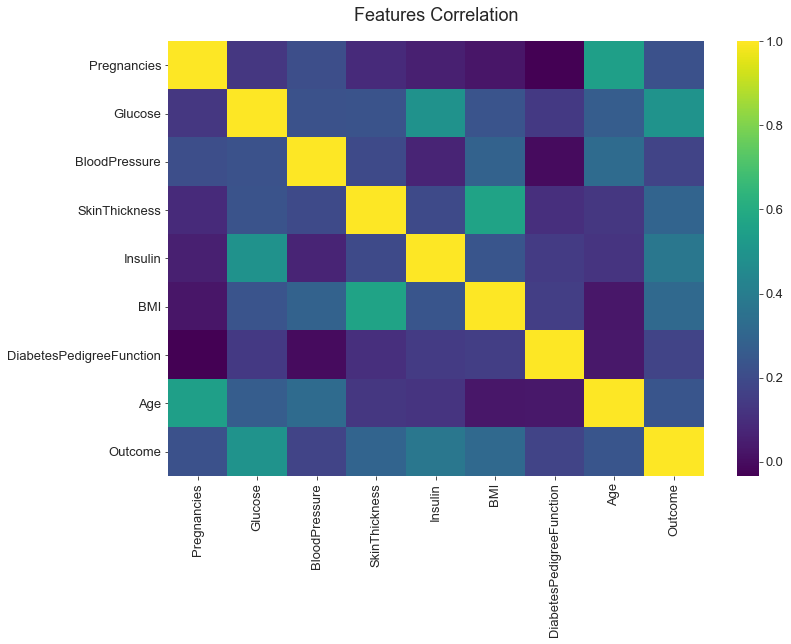

```python
plt.figure(figsize=(12,8))
sns.heatmap(df.corr(),cmap='viridis')
plt.title('Features Correlation',pad=20)
```

From the above correlation graph we can see that highly correlated features are Pregnancies vs Age, Glucose vs Insulin and SkinThickness vs BMI. We will first visualize these features and then explore other features as well.

### 4.1. Pregnancies vs Age

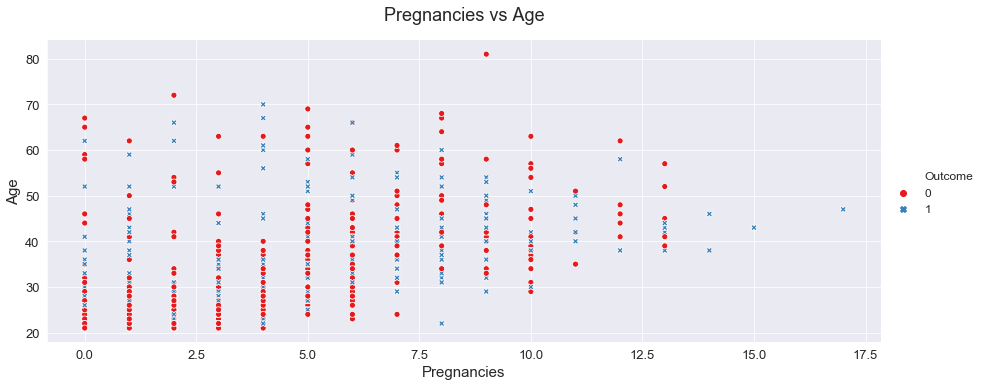

```python
feature_analysis('Pregnancies','Age')
```

Healthy females are concentrated with Age <= 30 and Pregnancies <= 6

### 4.2. Glucose vs Insulin

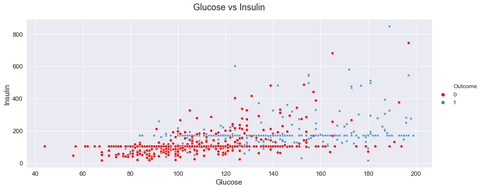

```python
feature_analysis('Glucose','Insulin')
```

Healthy females are concentrated with Insulin < 200 and Glucose <=120

### 4.3. SkinThickness vs BMI

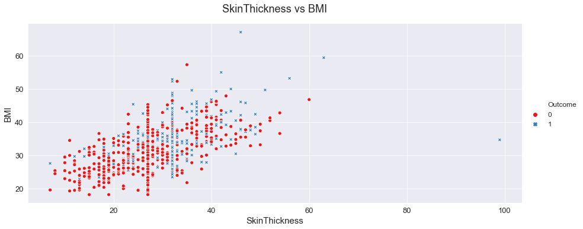

```python
feature_analysis('SkinThickness','BMI')
```

Healthy females are concentrated with BMI <= 30 and SkinThickness <= 20

### 4.4. Glucose vs Age

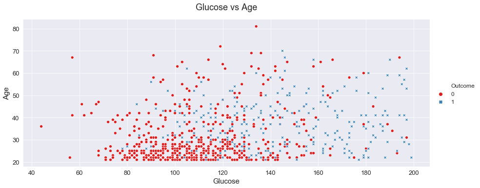

```python
feature_analysis('Glucose','Age')
```

Healthy females are concentrated with Age <= 30 and Glucose <= 120

### 4.5. Glucose vs BloodPressure

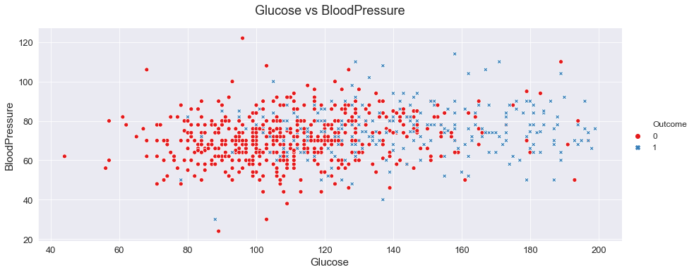

```python
feature_analysis('Glucose','BloodPressure')
```

Healthy females are concentrated with BloodPressure <= 80 and Glucose <= 120

### 4.6. Glucose vs BMI

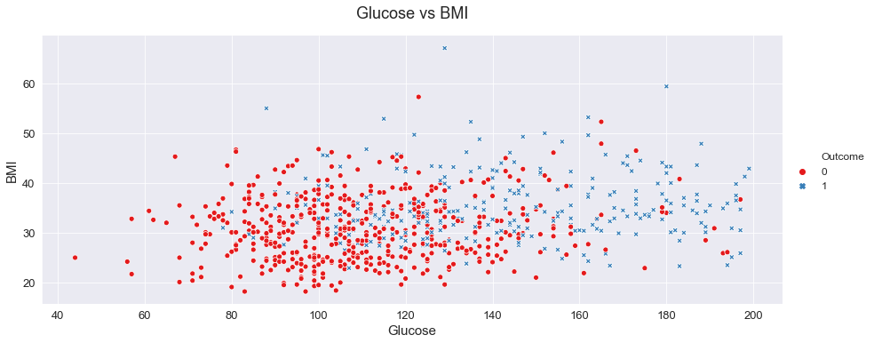

```python
feature_analysis('Glucose','BMI')
```

Healthy females are concentrated with BMI <= 30 and Glucose <= 120

All the insight that we gathered by analyzing the different features will be very usefull for our model.